# Owner Spend Regression

In this workbook we’ll build a model for owner spend in the month of August 2015. (The Wedge did a remodel project in February of 2016, so we want to be careful using time after that for our analysis.)

Let’s start by reading in a file of spend by owner and department by month and year. Feel free to substitute your file in for the one I’m providing–you should have something like this built for part 2 of the Wedge project.

Head of the Owner Data

| owner | dept_no | department | year | month | spend | transactions | items | segment |
| --- | --- | --- | --- | --- | --- | --- | --- | --- |
| 50944 | 1 | PACKAGED GROCERY | 2010 | 12 | 29.18 | 5 | 12 | Secondary |
| 50944 | 1 | PACKAGED GROCERY | 2011 | 5 | 25.49 | 3 | 11 | Secondary |
| 50944 | 1 | PACKAGED GROCERY | 2010 | 3 | 40.16 | 7 | 22 | Primary |
| 50944 | 1 | PACKAGED GROCERY | 2010 | 9 | 98.72 | 10 | 38 | Primary |
| 50944 | 1 | PACKAGED GROCERY | 2011 | 4 | 22.92 | 5 | 9 | Secondary |
| 50944 | 1 | PACKAGED GROCERY | 2011 | 2 | 15.35 | 1 | 5 | Secondary |

You should be pretty familiar with those fields except for “Segment”. That field is built based on some rules that we built back in 2015 to split owners into various categories. Let me know if you’d like to hear more about the process.

As always, let’s do some descriptive statistics. Here’s what `describe` has to say for us. We’re going to cut down the data to `segment != 'light' & year == 2015` just to make the code run snappier.

```
## d
##
##  9  Variables      824115  Observations
## ---------------------------------------------------------------------------
## owner
##        n  missing distinct     Info     Mean      Gmd      .05      .10
##   824115        0    16955        1    20232     8868    10898    11756
##      .25      .50      .75      .90      .95
##    14218    18472    22781    25391    48782
##
## lowest : 10000 10001 10002 10003 10004, highest: 63930 63973 64004 64125 64190
## ---------------------------------------------------------------------------
## dept_no
##        n  missing distinct     Info     Mean      Gmd      .05      .10
##   824115        0       18    0.992    6.482     5.02        1        1
##      .25      .50      .75      .90      .95
##        3        5       10       13       14
##
## Value           1      2      3      4      5      6      7      8      9
## Frequency  104385  95863  70147  90338  52443  51562  29843  81768  30178
## Proportion  0.127  0.116  0.085  0.110  0.064  0.063  0.036  0.099  0.037
##
## Value          10     11     12     13     14     16     17     18     22
## Frequency   30393  43289  28100  57786  26551  21081   1058   8257   1073
## Proportion  0.037  0.053  0.034  0.070  0.032  0.026  0.001  0.010  0.001
## ---------------------------------------------------------------------------
## department
##        n  missing distinct
##   824115        0       18
##
## BAKEHOUSE (1058, 0.001), BEER & WINE (1073, 0.001), BREAD (29843, 0.036),
## BULK (70147, 0.085), CHEESE (52443, 0.064), DELI (81768, 0.099),
## FISH&SEAFOOD (21081, 0.026), FLOWERS (8257, 0.010), FROZEN (51562, 0.063),
## GEN MERCH (30178, 0.037), HERBS&SPICES (28100, 0.034), JUICE BAR (26551,
## 0.032), MEAT (57786, 0.070), PACKAGED GROCERY (104385, 0.127), PERSONAL
## CARE (43289, 0.053), PRODUCE (95863, 0.116), REF GROCERY (90338, 0.110),
## SUPPLEMENTS (30393, 0.037)
## ---------------------------------------------------------------------------
## year
##        n  missing distinct     Info     Mean      Gmd
```

[output cut: 37 more lines]

```
## items
##        n  missing distinct     Info     Mean      Gmd      .05      .10
##   824115        0      606    0.975    7.609    9.664        1        1
##      .25      .50      .75      .90      .95
##        1        3        8       17       27
##
## lowest :  -10   -8   -7   -6   -5, highest: 4854 5020 5026 5029 5046
## ---------------------------------------------------------------------------
## segment
##        n  missing distinct
##   824115        0       21
##
## lowest : Light             Niche-BAKEHOUSE   Niche-BEER & WINE Niche-BREAD       Niche-BULK
## highest: Niche-PRODUCE     Niche-REF GROCERY Niche-SUPPLEMENTS Primary           Secondary
## ---------------------------------------------------------------------------
```

There are some *very* large spends in there. So that our regression model isn’t unduly influenced by these non-individual owners, let’s drop anyone with a department-level spend of more than $1,000 in a month. This isn’t perfect, and if we worked for the Wedge there would be better ways to clean this data, but it will get us started.

## Building Regression Data

We’d like to build a regression model that has spend in August 2015 as the response variable. Our explantory variables will be: * Spend in July * Spend in June * Number of departments shopped in previous seven months * Indicator variables for July shopping in Produce, Packaged Grocery, and Supplements.

There are a lot of ways to build up this data set, but since we’re easing our way back into R, I’ll do it in a slow-but-clear way so we can see what’s happening. Once we get `dplyr` (next week) we’ll see some faster ways.

```r
reg.d <- data.frame(owner=unique(d$owner[d$month==8 & d$year==2015]), # get owners
                    august=0, # placeholders
                    july=0,
                    june=0,
                    depts=0,
                    produce=0,
                    pck_groc=0,
                    supplements=0)

for (i in 1:nrow(reg.d)) {
  this.owner <- reg.d$owner[i]
  this.data <- d[d$owner==this.owner,]

  reg.d$august[i] <- sum(this.data$spend[this.data$month==8])
  reg.d$july[i] <- sum(this.data$spend[this.data$month==7])
  reg.d$june[i] <- sum(this.data$spend[this.data$month==6])
  reg.d$depts[i] <- length(unique(this.data$dept_no[this.data$month < 8]))
  reg.d$produce[i] <- ifelse("PRODUCE" %in% unique(this.data$department[this.data$month==7]),1,0)

  reg.d$pck_groc[i] <- ifelse("PACKAGED GROCERY" %in% unique(this.data$department[this.data$month==7]),1,0)

  reg.d$supplements[i] <- ifelse("SUPPLEMENTS" %in% unique(this.data$department[this.data$month==7]),1,0)

}
```

## Plotting the data

It’s always a good idea to look at the data before we start doing some modeling. Let’s look at the various columns of `reg.d` versus the response variable, `august`.

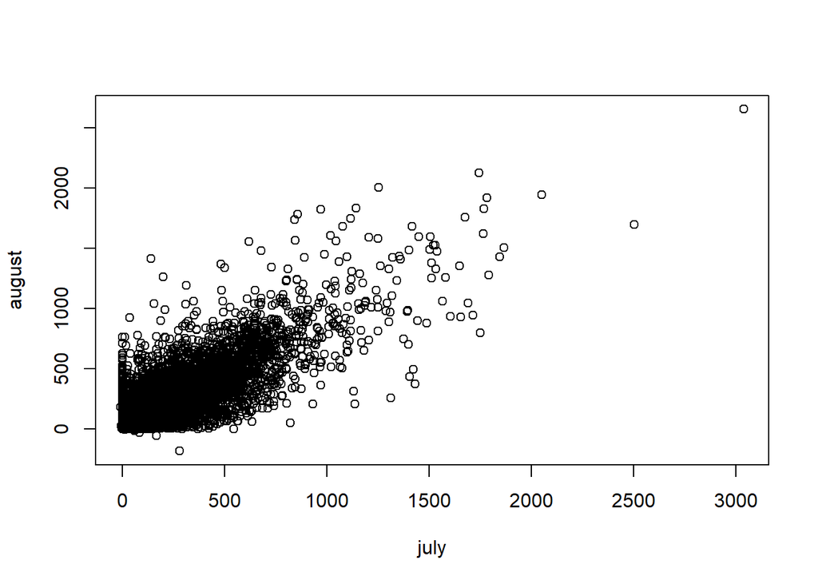

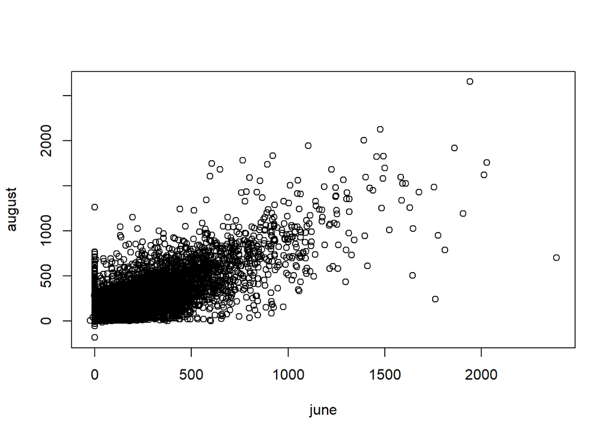

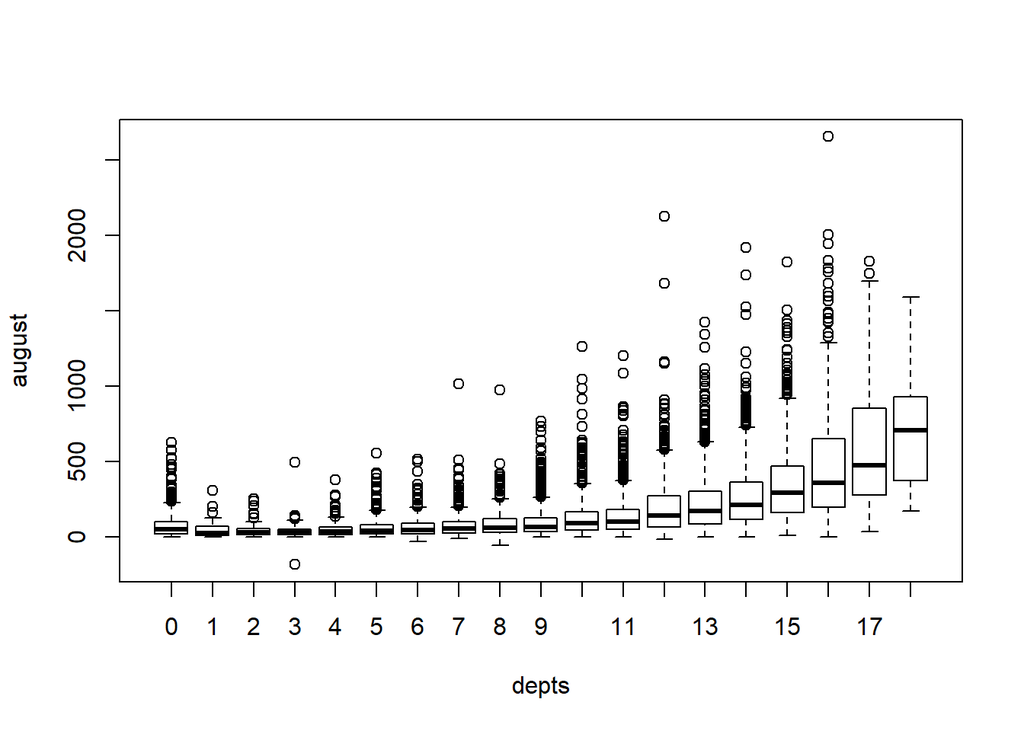

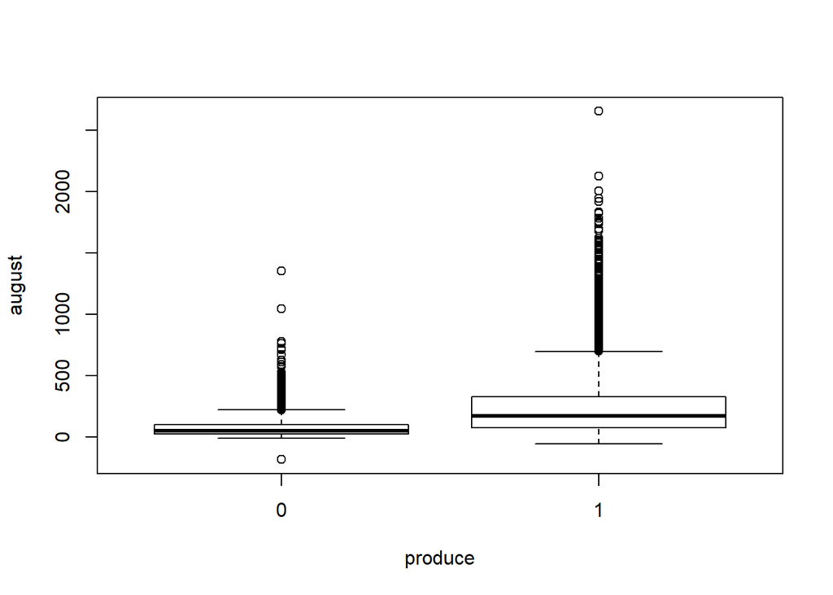

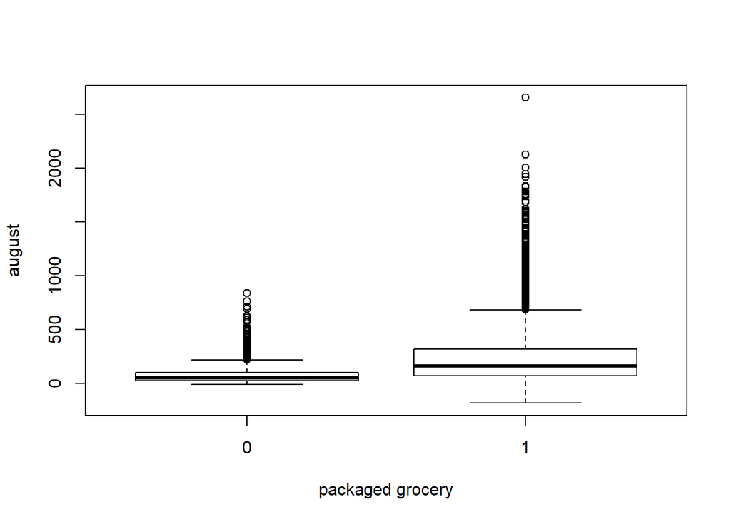

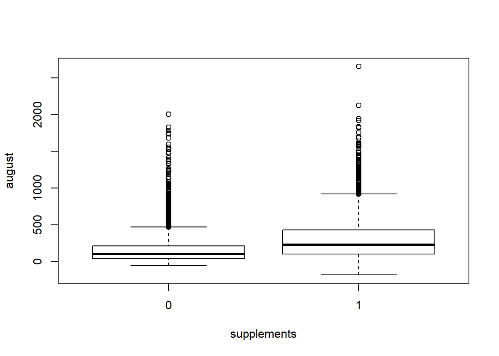

In the future when we make charts like this we can make them look much better (particularly using `ggplot`). We haven’t covered that yet, though, so I’ll just make one for you to show you how I’d prepare these in a more publication-worthy way.

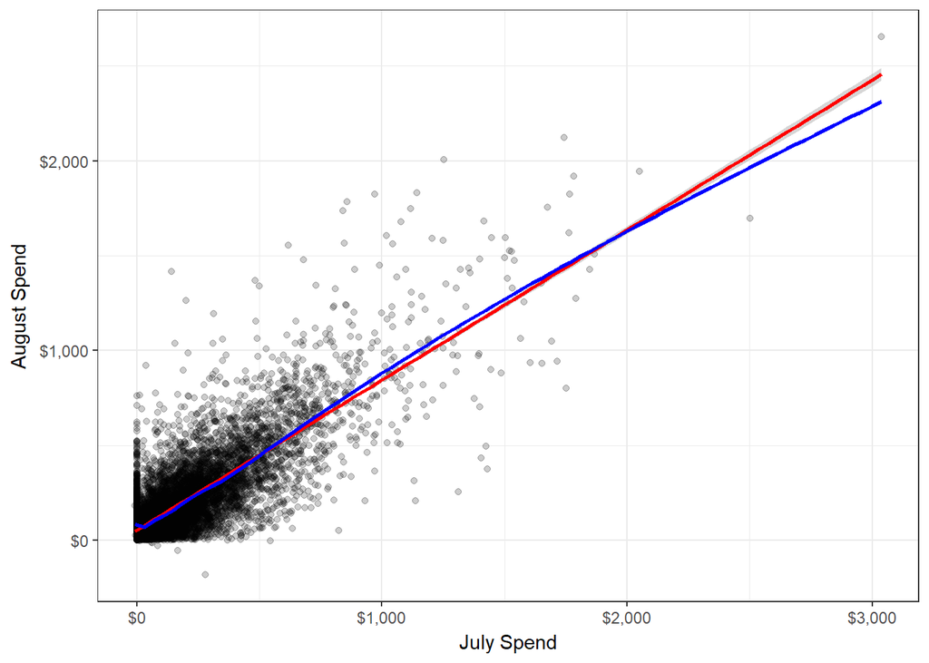

```r
library(ggplot2)
library(scales)

p <- ggplot(reg.d,
            aes(x=july,y=august)) +
  geom_point(alpha=0.2) +
  labs(x="July Spend",y="August Spend") +
  theme_bw() +
  scale_x_continuous(label=dollar) +
  scale_y_continuous(label=dollar) +
  stat_smooth(method="lm",col="red") +
  stat_smooth(col="blue",se=F)

print(p)
```

## Building a Model

Building models in R are pretty easy. Let’s create one and look at the summary-level information

```r
lm.1 <- lm(august ~ july + june + depts +
             produce + pck_groc + supplements,
           data=reg.d)

summary(lm.1)
```

```
##
## Call:
## lm(formula = august ~ july + june + depts + produce + pck_groc +
##     supplements, data = reg.d)
##
## Residuals:
##     Min      1Q  Median      3Q     Max
## -799.38  -56.70  -17.61   44.59 1129.53
##
## Coefficients:
##               Estimate Std. Error t value Pr(>|t|)
## (Intercept)  44.357296   3.567807  12.433  < 2e-16 ***
## july          0.529364   0.009963  53.132  < 2e-16 ***
## june          0.358336   0.009649  37.137  < 2e-16 ***
## depts         2.320214   0.413691   5.609 2.10e-08 ***
## produce     -12.016560   4.234860  -2.838  0.00456 **
## pck_groc    -28.284865   4.367715  -6.476 9.88e-11 ***
## supplements -16.222557   3.344722  -4.850 1.25e-06 ***
## ---
## Signif. codes:  0 '***' 0.001 '**' 0.01 '*' 0.05 '.' 0.1 ' ' 1
##
## Residual standard error: 122.4 on 9824 degrees of freedom
## Multiple R-squared:  0.7005, Adjusted R-squared:  0.7003
## F-statistic:  3829 on 6 and 9824 DF,  p-value: < 2.2e-16
```

The $R^2=0.7$, which is pretty respectable and our residual standard error is $122, which, again, seems pretty solid until we remember that the mean August spend is $193, so we’re missing by a pretty decent amount.

Spend some time thinking about what these coefficients mean. What would the estimate be for someone who spent $100 in June and July, shopped 10 departments, and shopped PRODUCE and SUPPLEMENTS in July? You can write some R code here to answer the question.

## Analyzing Residuals

Let’s add the residuals of the model to our regression data.

```r
reg.d$resids <- residuals(lm.1)
Hmisc::describe(reg.d$resids)
```

```
## reg.d$resids
##         n   missing  distinct      Info      Mean       Gmd       .05
##      9831         0      9818         1 1.773e-15     121.5   -157.61
##       .10       .25       .50       .75       .90       .95
##   -109.19    -56.70    -17.61     44.59    134.79    208.86
##
## lowest : -799.3801 -690.3959 -643.5223 -619.0997 -613.8734
## highest:  897.9181  927.3506  934.7022 1014.0709 1129.5315
```

```r
knitr::kable(subset(reg.d,resids < -500))
```

|  | owner | august | july | june | depts | produce | pck_groc | supplements | resids |
| --- | --- | --- | --- | --- | --- | --- | --- | --- | --- |
| 674 | 25284 | 242.32 | 160.00 | 1761.85 | 15 | 1 | 1 | 0 | -512.5716 |
| 838 | 18023 | 255.07 | 1311.80 | 304.77 | 17 | 1 | 1 | 1 | -575.8373 |
| 1176 | 18320 | 505.73 | 801.46 | 1644.45 | 15 | 1 | 1 | 1 | -530.4365 |
| 2518 | 17059 | 208.95 | 1138.12 | 566.32 | 15 | 1 | 1 | 1 | -619.0997 |
| 2545 | 15667 | 206.38 | 930.68 | 697.54 | 14 | 1 | 1 | 1 | -556.5589 |
| 2710 | 11690 | 375.82 | 1431.39 | 538.90 | 15 | 1 | 1 | 0 | -613.8734 |
| 4413 | 18487 | 700.21 | 800.63 | 2387.30 | 14 | 1 | 1 | 1 | -599.3868 |
| 4469 | 12356 | 49.57 | 822.92 | 747.35 | 14 | 1 | 1 | 0 | -690.3959 |
| 4510 | 19483 | 65.49 | 509.17 | 843.10 | 15 | 1 | 1 | 0 | -545.0186 |
| 5945 | 13361 | 432.71 | 1405.94 | 1298.22 | 15 | 1 | 1 | 1 | -799.3801 |
| 6207 | 48986 | -2.59 | 545.29 | 600.30 | 14 | 1 | 1 | 0 | -542.8951 |
| 7910 | 17178 | 363.21 | 970.17 | 946.56 | 16 | 1 | 1 | 1 | -514.5068 |
| 9191 | 12824 | 86.18 | 515.59 | 912.78 | 15 | 1 | 1 | 0 | -552.6960 |
| 9233 | 19192 | 149.53 | 622.99 | 925.28 | 15 | 1 | 1 | 0 | -550.6790 |
| 9737 | 11043 | 312.92 | 1129.96 | 910.83 | 12 | 1 | 1 | 0 | -643.5223 |

```r
knitr::kable(subset(reg.d,resids > 800))
```

|  | owner | august | july | june | depts | produce | pck_groc | supplements | resids |
| --- | --- | --- | --- | --- | --- | --- | --- | --- | --- |
| 802 | 15037 | 1749.52 | 1116.78 | 605.35 | 17 | 1 | 1 | 0 | 897.9181 |
| 1260 | 20817 | 1736.51 | 842.03 | 891.70 | 14 | 1 | 1 | 0 | 934.7022 |
| 5453 | 13929 | 1415.57 | 140.46 | 1046.52 | 15 | 1 | 1 | 0 | 927.3506 |
| 5561 | 20318 | 1783.46 | 857.22 | 765.84 | 16 | 1 | 1 | 0 | 1014.0709 |
| 5747 | 16143 | 1554.96 | 618.96 | 855.02 | 17 | 1 | 1 | 0 | 877.4206 |
| 6994 | 49598 | 1263.25 | 201.11 | 0.00 | 10 | 1 | 1 | 0 | 1129.5315 |
| 8626 | 19181 | 1832.71 | 1143.75 | 921.12 | 16 | 1 | 1 | 1 | 872.2222 |
| 9517 | 20192 | 1605.73 | 1018.21 | 595.06 | 17 | 1 | 1 | 1 | 826.2174 |
| 9674 | 18404 | 2004.90 | 1251.64 | 1391.26 | 16 | 1 | 1 | 0 | 802.6085 |

How would you describe what we’re seeing in this large and small residuals? What could you do to try to improve our model fit?

## Future Work

Here are some ways to extend this work if we’ve got more time: * Whatever you came up with immediately above! :-) * Extending to a rolling time horizon rather than having August 2015 as the only response variable. * Exploring additional covariates.